# US Name

Model estimate Estimate internal finance and pollution emission firm level

# Description

None

# Metadata

# Load tables

Since we load the data as a Pandas DataFrame, we want to pass the `dtypes`. We load the schema from Glue to guess the types

- 1=state -> 110 141 143 151
- 2=collective -> 120 130 142 149
- 3=private -171 172 173 174 190
- 4=foreign- 210 220 230 240
- 5=Hong Kong, Macau and Taiwan (4 and 5 can be combined into a single "foreign" category - 310 320 330 340

```
cic                      int64
industry_name           object
financial_dep_china    float64
financial_dep_us       float64
hum_cap_us             float64
phys_cap_us            float64
liquidity_need_us      float64
rd_intensity_us        float64
foreign_share_us       float64
dtype: object
```

|  | cic | industry_name | financial_dep_china | financial_dep_us | hum_cap_us | phys_cap_us | liquidity_need_us | rd_intensity_us | foreign_share_us |
| --- | --- | --- | --- | --- | --- | --- | --- | --- | --- |
| 0 | 16 | Tobacco | -1.54 | -0.45 | 1.35 | 0.02 | 0.25 | 0.0 | 0.02 |

```
(104699, 93)
```

```
(104285, 103)
```

```
quick_ratio    0
dtype: int64
```

|  | year | firm | name | geocode4_corr | province_en | cic_adj | cic03 | indu_2 | ownership_new | age | tfp_op | tfp_lp | output | outputdefl | sales | employment | capital | current_asset | tofixed | error | total_liabilities | total_asset | total_right | intangible | tangible | net_non_current | cashflow | current_ratio | quick_ratio | … |
| --- | --- | --- | --- | --- | --- | --- | --- | --- | --- | --- | --- | --- | --- | --- | --- | --- | --- | --- | --- | --- | --- | --- | --- | --- | --- | --- | --- | --- | --- | --- |
| 0 | 2006 | 100037 | 长治市三宝生化药业有限公司 | 1404 | Shanxi | 2760 | 2710 | 27 | 0.0 | 5.0 | 1.210186 | 5.25578 | 5842.0 | 1.095 | 8599.0 | 140.0 | 19960.0 | 14869 | 31133 | -5880 | 41957 | 67377 | 67377 | 17674 | 28954 | 46628 | 2179 | 0.38644 | 0.14403 | … |

## Create lags

```
        #log(lag_current_ratio) +
        log(sales) +
        log(total_asset) +
        log(lag_liabilities_tot_asset) +
        log(lag_sales_tot_asset)
```

|  | lag_asset_tangibility_tot_asset | lag_cashflow_to_tangible | lag_current_ratio | lag_quick_ratio | lag_sales | lag_total_asset | lag_liabilities_tot_asset | lag_sales_tot_asset | lag_tfp_op | lag_tfp_lp |
| --- | --- | --- | --- | --- | --- | --- | --- | --- | --- | --- |
| count | 62992.000000 | 62992.000000 | 62992.000000 | 62992.000000 | 6.299200e+04 | 6.299200e+04 | 62992.000000 | 62992.000000 | 61312.000000 | 61312.000000 |
| mean | 0.498408 | 0.170537 | 1.157386 | 0.253412 | 3.083760e+05 | 4.165033e+05 | 0.578738 | 0.975131 | 0.809244 | 7.164143 |
| std | 0.195867 | 0.763335 | 4.428319 | 1.419629 | 1.711420e+06 | 2.303661e+06 | 0.196293 | 1.092976 | 0.343691 | 1.190627 |
| min | 0.000050 | 0.000010 | 0.000170 | -0.680140 | 1.000000e+00 | 2.400000e+02 | 0.002130 | 0.000100 | -7.108141 | -1.214162 |
| 25% | 0.353128 | 0.048500 | 0.516158 | 0.047720 | 2.060725e+04 | 2.865950e+04 | 0.450540 | 0.451967 | 0.660216 | 6.349331 |
| 50% | 0.491860 | 0.092440 | 0.814610 | 0.131745 | 5.613600e+04 | 7.961000e+04 | 0.585870 | 0.715890 | 0.810496 | 7.102134 |
| 75% | 0.641502 | 0.175592 | 1.210990 | 0.273053 | 1.667962e+05 | 2.421325e+05 | 0.713550 | 1.143603 | 0.963511 | 7.906987 |
| max | 0.999930 | 120.000000 | 659.200000 | 173.333330 | 1.170000e+08 | 1.647260e+08 | 9.685200 | 59.606030 | 10.258273 | 12.529512 |

```
(62992, 113)
```

```
SOE    0
dtype: int64
```

|  | Name | Type |
| --- | --- | --- |
| 0 | year | string |
| 1 | firm | string |
| 2 | name | string |
| 3 | geocode4_corr | string |
| 4 | province_en | string |
| ... | ... | ... |
| 77 | hxxycsl | string |
| 78 | adcsl | string |
| 79 | eyhlcsl | string |
| 80 | dyhwcsl | string |
| 81 | yfccsl | string |

82 rows × 2 columns

## Schema Latex table

To rename a variable, please use the following template:

```
{
    'old':'XX',
    'new':'XX_1'
    }
```

if you need to pass a latex format with `\`, you need to duplicate it for instance, `\text` becomes `\text:

```
{
    'old':'working\_capital\_i',
    'new':'\\text{working capital}_i'
    }
```

Then add it to the key `to_rename`

```
 Hlavac, Marek (2018). stargazer: Well-Formatted Regression and Summary Statistics Tables.
 R package version 5.2.2. https://CRAN.R-project.org/package=stargazer
```

|  | share_o | lag_cashflow_to_tangible | lag_current_ratio | lag_sales_tot_asset | lag_liabilities_tot_asset | lag_asset_tangibility_tot_asset | lag_sales | lag_total_asset | lag_tfp_op | lag_tfp_lp |
| --- | --- | --- | --- | --- | --- | --- | --- | --- | --- | --- |
| count | 62992.000000 | 62992.000000 | 62992.000000 | 62992.000000 | 62992.000000 | 62992.000000 | 6.299200e+04 | 6.299200e+04 | 61312.000000 | 61312.000000 |
| mean | 1.831571 | 0.170537 | 1.157386 | 0.975131 | 0.578738 | 0.498408 | 3.083760e+05 | 4.165033e+05 | 0.809244 | 7.164143 |
| std | 9.733419 | 0.763335 | 4.428319 | 1.092976 | 0.196293 | 0.195867 | 1.711420e+06 | 2.303661e+06 | 0.343691 | 1.190627 |
| min | 0.000000 | 0.000010 | 0.000170 | 0.000100 | 0.002130 | 0.000050 | 1.000000e+00 | 2.400000e+02 | -7.108141 | -1.214162 |
| 0% | 0.000000 | 0.000010 | 0.000170 | 0.000100 | 0.002130 | 0.000050 | 1.000000e+00 | 2.400000e+02 | -7.108141 | -1.214162 |
| 5% | 0.000000 | 0.012900 | 0.206540 | 0.214196 | 0.242980 | 0.185686 | 6.801000e+03 | 8.660550e+03 | 0.341280 | 5.393961 |
| 10% | 0.000000 | 0.023871 | 0.304401 | 0.289411 | 0.322955 | 0.244614 | 9.836000e+03 | 1.304810e+04 | 0.490546 | 5.742855 |
| 15% | 0.000000 | 0.032470 | 0.380007 | 0.347077 | 0.374783 | 0.287560 | 1.299300e+04 | 1.760400e+04 | 0.567004 | 5.977832 |
| 20% | 0.000622 | 0.040820 | 0.451140 | 0.400260 | 0.416274 | 0.321904 | 1.655240e+04 | 2.257340e+04 | 0.618408 | 6.179117 |
| 25% | 0.014389 | 0.048500 | 0.516158 | 0.451967 | 0.450540 | 0.353128 | 2.060725e+04 | 2.865950e+04 | 0.660216 | 6.349331 |
| 30% | 0.037729 | 0.056270 | 0.576579 | 0.501070 | 0.481690 | 0.382783 | 2.554400e+04 | 3.556260e+04 | 0.695057 | 6.513683 |
| 35% | 0.070058 | 0.064740 | 0.634941 | 0.552329 | 0.509890 | 0.410127 | 3.126585e+04 | 4.381485e+04 | 0.726395 | 6.666172 |
| 40% | 0.111419 | 0.073384 | 0.694434 | 0.603652 | 0.536104 | 0.437374 | 3.807580e+04 | 5.385140e+04 | 0.755956 | 6.811812 |
| 45% | 0.166575 | 0.082530 | 0.753570 | 0.657039 | 0.561209 | 0.464299 | 4.612995e+04 | 6.537480e+04 | 0.783018 | 6.957123 |
| 50% | 0.236513 | 0.092440 | 0.814610 | 0.715890 | 0.585870 | 0.491860 | 5.613600e+04 | 7.961000e+04 | 0.810496 | 7.102134 |
| 55% | 0.330648 | 0.104191 | 0.879220 | 0.778730 | 0.609980 | 0.519111 | 6.899625e+04 | 9.728700e+04 | 0.837412 | 7.249577 |
| 60% | 0.455291 | 0.116936 | 0.947324 | 0.850828 | 0.634466 | 0.547296 | 8.485560e+04 | 1.189656e+05 | 0.865624 | 7.401507 |
| 65% | 0.623256 | 0.132361 | 1.024512 | 0.934020 | 0.660230 | 0.576701 | 1.046276e+05 | 1.480783e+05 | 0.895288 | 7.562431 |
| 70% | 0.849472 | 0.151650 | 1.107267 | 1.028977 | 0.685710 | 0.608307 | 1.301342e+05 | 1.876558e+05 | 0.927591 | 7.727217 |
| 75% | 1.180420 | 0.175592 | 1.210990 | 1.143603 | 0.713550 | 0.641502 | 1.667962e+05 | 2.421325e+05 | 0.963511 | 7.906987 |
| 80% | 1.668455 | 0.208570 | 1.340590 | 1.289178 | 0.745220 | 0.677780 | 2.213718e+05 | 3.195084e+05 | 1.004788 | 8.112802 |
| 85% | 2.465552 | 0.252964 | 1.510318 | 1.505150 | 0.782584 | 0.718714 | 3.128917e+05 | 4.440071e+05 | 1.056295 | 8.365204 |
| 90% | 3.852477 | 0.331106 | 1.792115 | 1.824130 | 0.827149 | 0.767520 | 4.900175e+05 | 6.857803e+05 | 1.126858 | 8.687392 |
| 95% | 7.349645 | 0.506150 | 2.458060 | 2.511409 | 0.886624 | 0.830489 | 9.893630e+05 | 1.400378e+06 | 1.252880 | 9.193902 |
| max | 950.413223 | 120.000000 | 659.200000 | 59.606030 | 9.685200 | 0.999930 | 1.170000e+08 | 1.647260e+08 | 10.258273 | 12.529512 |

### Replicate tables

```
array([2007, 1999, 2000, 2003, 2004, 2001, 2002, 2006, 2005, 1998])
```

|  | tfp_op | tfp_lp | lag_tfp_op | lag_tfp_lp |
| --- | --- | --- | --- | --- |
| 1 | 0.937862 | 6.618081 | 1.210186 | 5.255780 |
| 4 | 0.767852 | 7.756062 | 0.859182 | 7.907065 |
| 5 | 0.716815 | 7.823079 | 0.767852 | 7.756062 |
| 7 | 0.901573 | 7.001330 | 0.914743 | 6.987077 |
| 11 | 0.736353 | 6.763509 | 0.651615 | 6.683140 |
| ... | ... | ... | ... | ... |
| 104266 | 1.054381 | 7.468152 | 0.935627 | 7.156808 |
| 104267 | 1.169463 | 7.669288 | 1.054381 | 7.468152 |
| 104268 | 1.250156 | 7.815806 | 1.169463 | 7.669288 |
| 104269 | 1.333957 | 8.208723 | 1.250156 | 7.815806 |
| 104271 | 1.163101 | 7.129829 | 1.201693 | 7.736147 |

62992 rows × 4 columns

Table 1

|  | year | firm | name | geocode4_corr | province_en | cic_adj | cic03 | indu_2 | ownership_new | age | tfp_op | tfp_lp | output | outputdefl | sales | employment | capital | current_asset | tofixed | error | total_liabilities | total_asset | total_right | intangible | tangible | net_non_current | cashflow | current_ratio | quick_ratio | … |
| --- | --- | --- | --- | --- | --- | --- | --- | --- | --- | --- | --- | --- | --- | --- | --- | --- | --- | --- | --- | --- | --- | --- | --- | --- | --- | --- | --- | --- | --- | --- |
| 1 | 2007 | 100037 | 长治市三宝生化药业有限公司 | 1404 | Shanxi | 2760 | 2710 | 27 | 5.0 | 6.0 | 0.937862 | 6.618081 | 27600.0 | 1.13 | 26430.0 | 124.0 | 19960.0 | 16394 | 31843 | -23691 | 46162 | 69705 | 69705 | 0 | 29620 | 29620 | 2223 | 0.38545 | 0.12226 | … |

[figure not shown]

### Ownership

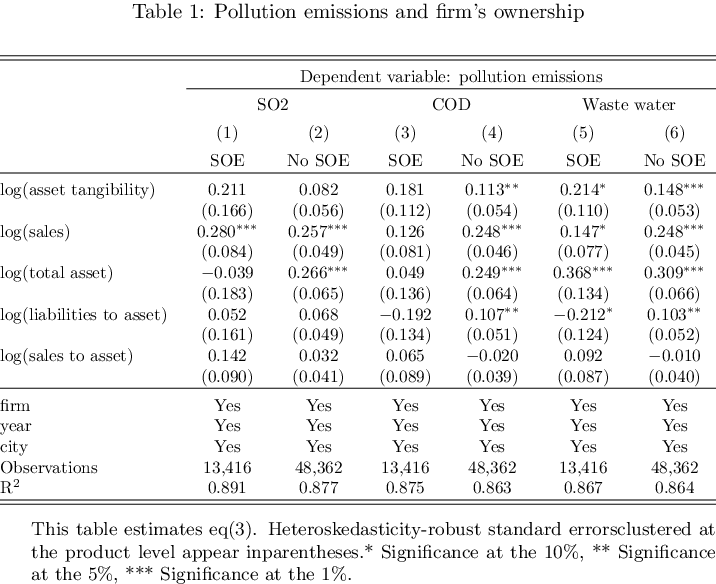

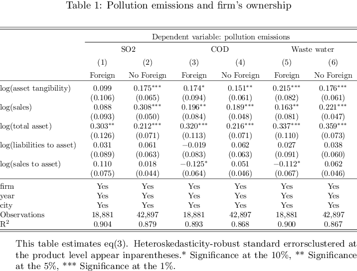

|  | year | firm | name | geocode4_corr | province_en | cic_adj | cic03 | indu_2 | ownership_new | age | tfp_op | tfp_lp | output | outputdefl | sales | employment | capital | current_asset | tofixed | error | total_liabilities | total_asset | total_right | intangible | tangible | net_non_current | cashflow | current_ratio | quick_ratio | … |
| --- | --- | --- | --- | --- | --- | --- | --- | --- | --- | --- | --- | --- | --- | --- | --- | --- | --- | --- | --- | --- | --- | --- | --- | --- | --- | --- | --- | --- | --- | --- |
| 1 | 2007 | 100037 | 长治市三宝生化药业有限公司 | 1404 | Shanxi | 2760 | 2710 | 27 | 5.0 | 6.0 | 0.937862 | 6.618081 | 27600.0 | 1.13 | 26430.0 | 124.0 | 19960.0 | 16394 | 31843 | -23691 | 46162 | 69705 | 69705 | 0 | 29620 | 29620 | 2223 | 0.38545 | 0.12226 | … |

|  | year | cic_adj | output | sales | employment | total_asset |
| --- | --- | --- | --- | --- | --- | --- |
| 0 | 1998 | 1320 | 12620.0 | 11615.0 | 226.0 | 9677.0 |
| 1 | 1998 | 1340 | 414280.0 | 432996.0 | 4203.0 | 1425566.0 |
| 2 | 1998 | 1352 | 36346.0 | 35983.0 | 878.0 | 103494.0 |
| 3 | 1998 | 1391 | 69480.0 | 66750.0 | 270.0 | 22308.0 |
| 4 | 1998 | 1392 | 28613.0 | 28563.0 | 242.0 | 29343.0 |
| ... | ... | ... | ... | ... | ... | ... |
| 3429 | 2007 | 4217 | 263408.0 | 251438.0 | 1325.0 | 142701.0 |
| 3430 | 2007 | 4218 | 840986.0 | 632175.0 | 306.5 | 295465.0 |
| 3431 | 2007 | 4219 | 73369.5 | 75784.0 | 629.0 | 40561.5 |
| 3432 | 2007 | 4222 | 82300.0 | 82030.0 | 347.0 | 86187.0 |
| 3433 | 2007 | 4229 | 278860.0 | 308261.5 | 677.5 | 531271.5 |

3434 rows × 6 columns

### TZC/SPZ

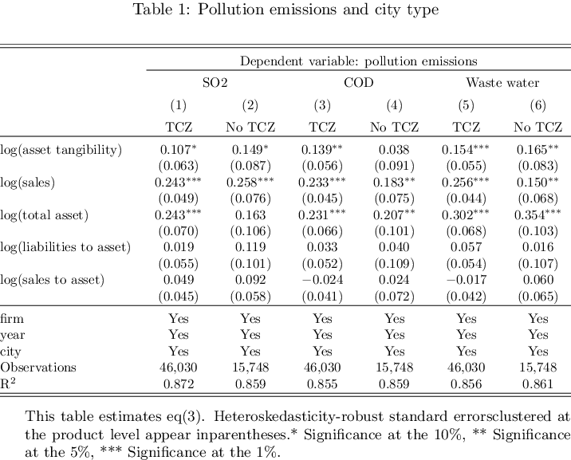

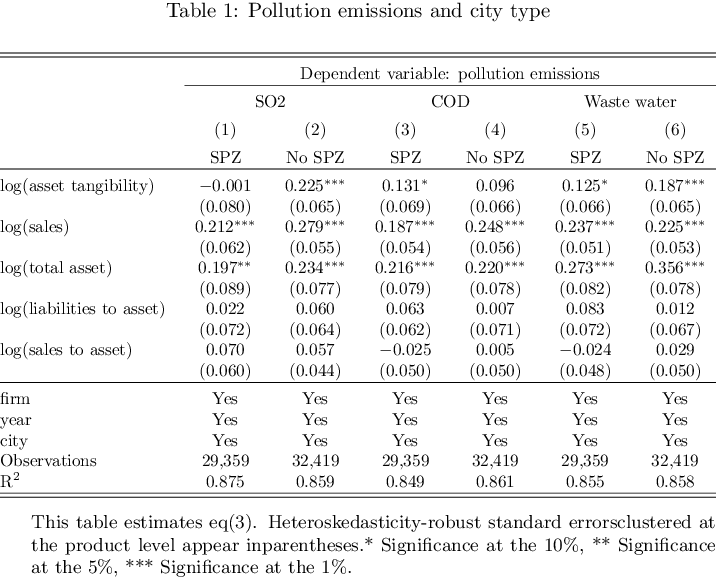

### Constraint

|  | year | firm | name | geocode4_corr | province_en | cic_adj | cic03 | indu_2 | ownership_new | age | tfp_op | tfp_lp | output | outputdefl | sales | employment | capital | current_asset | tofixed | error | total_liabilities | total_asset | total_right | intangible | tangible | net_non_current | cashflow | current_ratio | quick_ratio | … |
| --- | --- | --- | --- | --- | --- | --- | --- | --- | --- | --- | --- | --- | --- | --- | --- | --- | --- | --- | --- | --- | --- | --- | --- | --- | --- | --- | --- | --- | --- | --- |
| 1 | 2007 | 100037 | 长治市三宝生化药业有限公司 | 1404 | Shanxi | 2760 | 2710 | 27 | 5.0 | 6.0 | 0.937862 | 6.618081 | 27600.0 | 1.13 | 26430.0 | 124.0 | 19960.0 | 16394 | 31843 | -23691 | 46162 | 69705 | 69705 | 0 | 29620 | 29620 | 2223 | 0.38545 | 0.12226 | … |

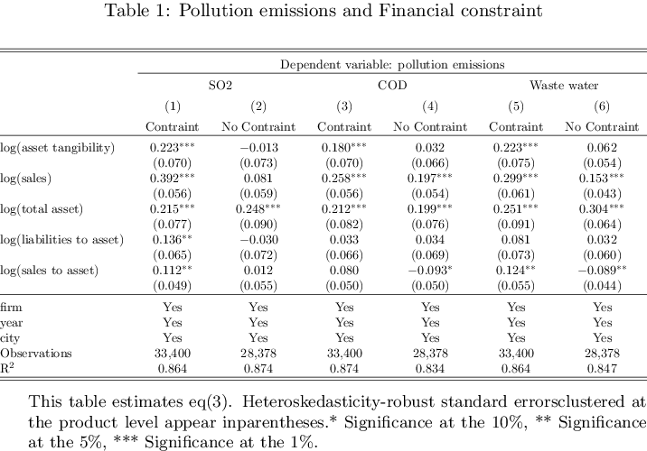

### Transmission channel

Faire avec taille

Regarder l'hétérogénéity, SOE/foreign/taille

- Changer de polluants

Est ce que l'accès a la finance interne affecte les emissions.

Une entreprise publique/large est moins sensible a la contrainte de crédit.

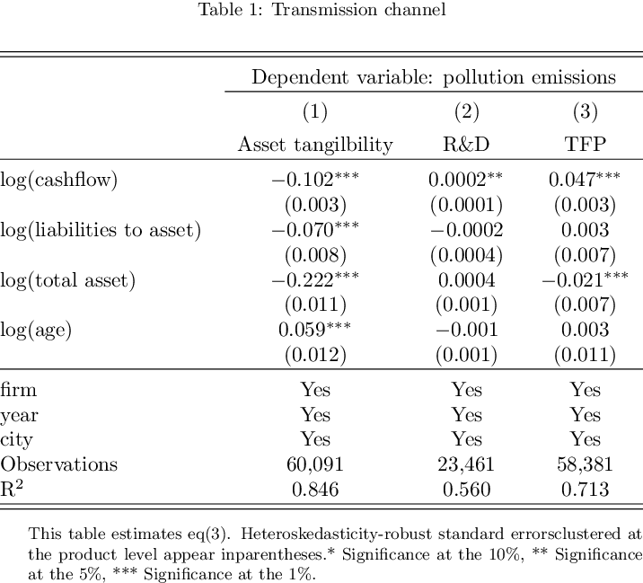

# Replicate one internal finance

-> prendre que asset tangilbilty et mettre les polluants, on explique que asset tangiblity

Mecanisme:

Cashflow

- Journal:
  - Environment and development economics: https://www.cambridge.org/core/journals/environment-and-development-economics
  - Review of environmental econ and policy: https://www.journals.uchicago.edu/toc/reep/current